# Data621_hw5

Wei Zhou / Mia Chen

5/16/2020

install.packages(“DataExplorer”) install.packages(“corrplot”) install.packages(“leaps”) install.packages(“mlogit”) install.packages(“lattice”)

```r
library(ggplot2)
library(stringr)
library(corrplot)
library(DataExplorer)
library(leaps)
library(mlogit)
library(reshape2)
```

# Introduction

### In this homework, I will explore, analyze and model a data set containing approximately 12,000 commercially available wines.The variable are mostly related to the chemical properties of the wine being sold. The response variable is the number of sample cases of wine that were purchased by wine distribution companies after sampling a wine. These cases would be used to provide tasting samples to restaurants and wine stores around United States. The more sample cases purchased, the more likely is a wine to be sold at a high end restaurant. A large wine manufacturer is studying the data in order to predict the number of wine cases ordered based upon the wine characteristics. If the wine manufacturer can predict the number of cases, then that manufacturer will be able to adjust their wine offering to maximize sales.

### My objective is to build a count regression model to predict the number of cases of wine that will be sold given certain properties of the wine.

### Read the data set

```r
train_data <- read.csv("https://raw.githubusercontent.com/JennierJ/DATA621/master/Homework5/wine-training-data.csv", header = TRUE)
eval_data <- read.csv("https://raw.githubusercontent.com/JennierJ/DATA621/master/Homework5/wine-evaluation-data.csv", header = TRUE)
```

## Data Exploration and Cleaning

```r
head(train_data)
```

```
##   INDEX TARGET FixedAcidity VolatileAcidity CitricAcid ResidualSugar Chlorides
## 1     1      3          3.2           1.160      -0.98          54.2    -0.567
## 2     2      3          4.5           0.160      -0.81          26.1    -0.425
## 3     4      5          7.1           2.640      -0.88          14.8     0.037
## 4     5      3          5.7           0.385       0.04          18.8    -0.425
## 5     6      4          8.0           0.330      -1.26           9.4        NA
## 6     7      0         11.3           0.320       0.59           2.2     0.556
##   FreeSulfurDioxide TotalSulfurDioxide Density   pH Sulphates Alcohol
## 1                NA                268 0.99280 3.33     -0.59     9.9
## 2                15               -327 1.02792 3.38      0.70      NA
## 3               214                142 0.99518 3.12      0.48    22.0
## 4                22                115 0.99640 2.24      1.83     6.2
## 5              -167                108 0.99457 3.12      1.77    13.7
## 6               -37                 15 0.99940 3.20      1.29    15.4
##   LabelAppeal AcidIndex STARS
## 1           0         8     2
## 2          -1         7     3
## 3          -1         8     3
## 4          -1         6     1
## 5           0         9     2
## 6           0        11    NA
```

```r
summary(train_data)
```

```
##      INDEX           TARGET       FixedAcidity     VolatileAcidity
##  Min.   :    1   Min.   :0.000   Min.   :-18.100   Min.   :-2.7900
##  1st Qu.: 4038   1st Qu.:2.000   1st Qu.:  5.200   1st Qu.: 0.1300
##  Median : 8110   Median :3.000   Median :  6.900   Median : 0.2800
##  Mean   : 8070   Mean   :3.029   Mean   :  7.076   Mean   : 0.3241
##  3rd Qu.:12106   3rd Qu.:4.000   3rd Qu.:  9.500   3rd Qu.: 0.6400
##  Max.   :16129   Max.   :8.000   Max.   : 34.400   Max.   : 3.6800
##
##    CitricAcid      ResidualSugar        Chlorides       FreeSulfurDioxide
##  Min.   :-3.2400   Min.   :-127.800   Min.   :-1.1710   Min.   :-555.00
##  1st Qu.: 0.0300   1st Qu.:  -2.000   1st Qu.:-0.0310   1st Qu.:   0.00
##  Median : 0.3100   Median :   3.900   Median : 0.0460   Median :  30.00
##  Mean   : 0.3084   Mean   :   5.419   Mean   : 0.0548   Mean   :  30.85
##  3rd Qu.: 0.5800   3rd Qu.:  15.900   3rd Qu.: 0.1530   3rd Qu.:  70.00
##  Max.   : 3.8600   Max.   : 141.150   Max.   : 1.3510   Max.   : 623.00
##                    NA's   :616        NA's   :638       NA's   :647
##  TotalSulfurDioxide    Density             pH          Sulphates
##  Min.   :-823.0     Min.   :0.8881   Min.   :0.480   Min.   :-3.1300
##  1st Qu.:  27.0     1st Qu.:0.9877   1st Qu.:2.960   1st Qu.: 0.2800
##  Median : 123.0     Median :0.9945   Median :3.200   Median : 0.5000
##  Mean   : 120.7     Mean   :0.9942   Mean   :3.208   Mean   : 0.5271
##  3rd Qu.: 208.0     3rd Qu.:1.0005   3rd Qu.:3.470   3rd Qu.: 0.8600
##  Max.   :1057.0     Max.   :1.0992   Max.   :6.130   Max.   : 4.2400
##  NA's   :682                         NA's   :395     NA's   :1210
##     Alcohol       LabelAppeal          AcidIndex          STARS
##  Min.   :-4.70   Min.   :-2.000000   Min.   : 4.000   Min.   :1.000
##  1st Qu.: 9.00   1st Qu.:-1.000000   1st Qu.: 7.000   1st Qu.:1.000
##  Median :10.40   Median : 0.000000   Median : 8.000   Median :2.000
##  Mean   :10.49   Mean   :-0.009066   Mean   : 7.773   Mean   :2.042
##  3rd Qu.:12.40   3rd Qu.: 1.000000   3rd Qu.: 8.000   3rd Qu.:3.000
##  Max.   :26.50   Max.   : 2.000000   Max.   :17.000   Max.   :4.000
##  NA's   :653                                          NA's   :3359
```

```r
nrow(train_data)
```

```
## [1] 12795
```

```r
train_data <- train_data[, -1]
eval_data <- eval_data[, -1]
summary(eval_data)
```

```
##   TARGET         FixedAcidity     VolatileAcidity     CitricAcid
##  Mode:logical   Min.   :-18.200   Min.   :-2.8300   Min.   :-3.1200
##  NA's:3335      1st Qu.:  5.200   1st Qu.: 0.0800   1st Qu.: 0.0000
##                 Median :  6.900   Median : 0.2800   Median : 0.3100
##                 Mean   :  6.864   Mean   : 0.3103   Mean   : 0.3124
##                 3rd Qu.:  9.000   3rd Qu.: 0.6300   3rd Qu.: 0.6050
##                 Max.   : 33.500   Max.   : 3.6100   Max.   : 3.7600
##
##  ResidualSugar        Chlorides        FreeSulfurDioxide TotalSulfurDioxide
##  Min.   :-128.300   Min.   :-1.15000   Min.   :-563.00   Min.   :-769.00
##  1st Qu.:  -2.600   1st Qu.: 0.01600   1st Qu.:   3.00   1st Qu.:  27.25
##  Median :   3.600   Median : 0.04700   Median :  30.00   Median : 124.00
##  Mean   :   5.319   Mean   : 0.06143   Mean   :  34.95   Mean   : 123.41
##  3rd Qu.:  17.200   3rd Qu.: 0.17100   3rd Qu.:  79.25   3rd Qu.: 210.00
##  Max.   : 145.400   Max.   : 1.26300   Max.   : 617.00   Max.   :1004.00
##  NA's   :168        NA's   :138        NA's   :152       NA's   :157
##     Density             pH          Sulphates          Alcohol
##  Min.   :0.8898   Min.   :0.600   Min.   :-3.0700   Min.   :-4.20
##  1st Qu.:0.9883   1st Qu.:2.980   1st Qu.: 0.3300   1st Qu.: 9.00
##  Median :0.9946   Median :3.210   Median : 0.5000   Median :10.40
##  Mean   :0.9947   Mean   :3.237   Mean   : 0.5346   Mean   :10.58
##  3rd Qu.:1.0005   3rd Qu.:3.490   3rd Qu.: 0.8200   3rd Qu.:12.50
##  Max.   :1.0998   Max.   :6.210   Max.   : 4.1800   Max.   :25.60
##                   NA's   :104     NA's   :310       NA's   :185
##   LabelAppeal         AcidIndex          STARS
##  Min.   :-2.00000   Min.   : 5.000   Min.   :1.00
##  1st Qu.:-1.00000   1st Qu.: 7.000   1st Qu.:1.00
##  Median : 0.00000   Median : 8.000   Median :2.00
##  Mean   : 0.01349   Mean   : 7.748   Mean   :2.04
##  3rd Qu.: 1.00000   3rd Qu.: 8.000   3rd Qu.:3.00
##  Max.   : 2.00000   Max.   :17.000   Max.   :4.00
##                                      NA's   :841
```

## Histograms

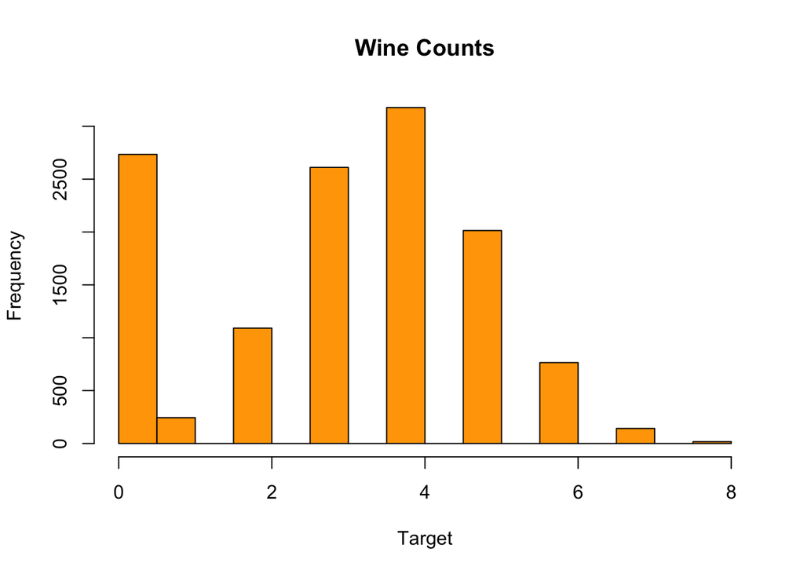

```r
hist(train_data$TARGET, col = "orange", xlab = " Target ", main = "Wine Counts")
```

## Boxplot

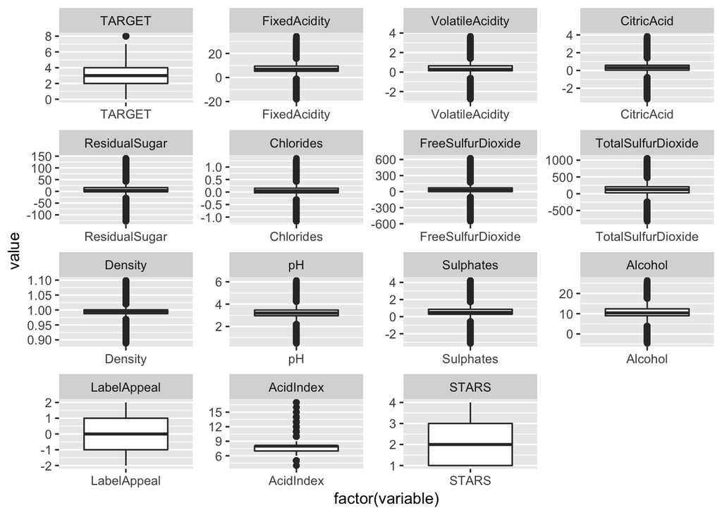

```r
ggplot(melt(train_data), aes(x=factor(variable), y=value)) + facet_wrap(~variable, scale="free") + geom_boxplot()
```

## Correlation

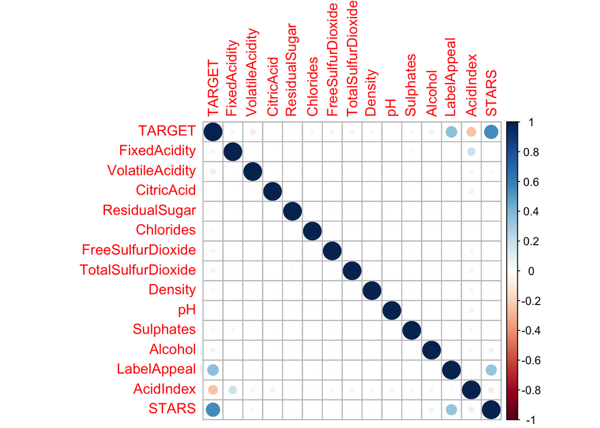

```r
corrplot(as.matrix(cor(train_data, use = "pairwise.complete")),method = "circle")
```

## Data Preparation

```r
# Replacing N/A with mean for calculation
train_data$ResidualSugar[is.na(train_data$ResidualSugar)] <- mean(train_data$ResidualSugar, na.rm=TRUE)
train_data$Chlorides[is.na(train_data$Chlorides)] <- mean(train_data$Chlorides, na.rm=TRUE)
train_data$FreeSulfurDioxide[is.na(train_data$FreeSulfurDioxide)] <- mean(train_data$FreeSulfurDioxide, na.rm=TRUE)
train_data$TotalSulfurDioxide[is.na(train_data$TotalSulfurDioxide)] <- mean(train_data$TotalSulfurDioxide, na.rm=TRUE)
train_data$pH[is.na(train_data$pH)] <- mean(train_data$pH, na.rm=TRUE)
train_data$Sulphates[is.na(train_data$Sulphates)] <- mean(train_data$Sulphates, na.rm=TRUE)
train_data$Sulphates[is.na(train_data$Sulphates)] <- mean(train_data$Sulphates, na.rm=TRUE)
train_data$Alcohol[is.na(train_data$Alcohol)] <- mean(train_data$Alcohol, na.rm=TRUE)
train_data$STARS[is.na(train_data$STARS)] <- mean(train_data$STARS, na.rm=TRUE)
eval_data$ResidualSugar[is.na(eval_data$ResidualSugar)] <- mean(eval_data$ResidualSugar, na.rm=TRUE)
eval_data$Chlorides[is.na(eval_data$Chlorides)] <- mean(eval_data$Chlorides, na.rm=TRUE)
eval_data$FreeSulfurDioxide[is.na(eval_data$FreeSulfurDioxide)] <- mean(eval_data$FreeSulfurDioxide, na.rm=TRUE)
eval_data$TotalSulfurDioxide[is.na(eval_data$TotalSulfurDioxide)] <- mean(eval_data$TotalSulfurDioxide, na.rm=TRUE)
eval_data$pH[is.na(eval_data$pH)] <- mean(eval_data$pH, na.rm=TRUE)
eval_data$Sulphates[is.na(eval_data$Sulphates)] <- mean(eval_data$Sulphates, na.rm=TRUE)
eval_data$Alcohol[is.na(eval_data$Alcohol)] <- mean(eval_data$Alcohol, na.rm=TRUE)
eval_data$STARS[is.na(eval_data$STARS)] <- mean(eval_data$STARS, na.rm=TRUE)
```

## Build Model

```r
# Possion Distribution
model1 = glm(TARGET ~., data = train_data, family = poisson)
summary(model1)
```

```
##
## Call:
## glm(formula = TARGET ~ ., family = poisson, data = train_data)
##
## Deviance Residuals:
##     Min       1Q   Median       3Q      Max
## -3.5118  -0.5144   0.2080   0.6344   2.5664
##
## Coefficients:
##                      Estimate Std. Error z value Pr(>|z|)
## (Intercept)         2.045e+00  1.957e-01  10.448  < 2e-16 ***
## FixedAcidity       -4.444e-04  8.194e-04  -0.542 0.587585
## VolatileAcidity    -5.097e-02  6.492e-03  -7.851 4.12e-15 ***
## CitricAcid          1.343e-02  5.892e-03   2.280 0.022631 *
## ResidualSugar       1.489e-04  1.545e-04   0.964 0.335073
## Chlorides          -6.058e-02  1.645e-02  -3.683 0.000231 ***
## FreeSulfurDioxide   1.420e-04  3.513e-05   4.041 5.31e-05 ***
## TotalSulfurDioxide  1.072e-04  2.268e-05   4.727 2.28e-06 ***
## Density            -4.364e-01  1.921e-01  -2.272 0.023074 *
## pH                 -2.411e-02  7.639e-03  -3.156 0.001599 **
## Sulphates          -1.901e-02  5.738e-03  -3.313 0.000924 ***
## Alcohol             5.528e-03  1.410e-03   3.920 8.85e-05 ***
## LabelAppeal         1.996e-01  6.014e-03  33.180  < 2e-16 ***
## AcidIndex          -1.232e-01  4.461e-03 -27.616  < 2e-16 ***
## STARS               2.113e-01  6.491e-03  32.543  < 2e-16 ***
## ---
## Signif. codes:  0 '***' 0.001 '**' 0.01 '*' 0.05 '.' 0.1 ' ' 1
##
## (Dispersion parameter for poisson family taken to be 1)
##
##     Null deviance: 22861  on 12794  degrees of freedom
## Residual deviance: 18511  on 12780  degrees of freedom
## AIC: 50483
##
## Number of Fisher Scoring iterations: 5
```

```r
# Exclude the predictor that are not significant
model2 = glm(TARGET ~ VolatileAcidity + CitricAcid + Chlorides + FreeSulfurDioxide
                        + TotalSulfurDioxide + Density + pH + Sulphates + Alcohol + LabelAppeal
             + AcidIndex + STARS, data = train_data,
             family = poisson)
summary(model2)
```

```
##
## Call:
## glm(formula = TARGET ~ VolatileAcidity + CitricAcid + Chlorides +
##     FreeSulfurDioxide + TotalSulfurDioxide + Density + pH + Sulphates +
##     Alcohol + LabelAppeal + AcidIndex + STARS, family = poisson,
##     data = train_data)
##
## Deviance Residuals:
##     Min       1Q   Median       3Q      Max
## -3.5135  -0.5169   0.2084   0.6350   2.5697
##
## Coefficients:
##                      Estimate Std. Error z value Pr(>|z|)
## (Intercept)         2.045e+00  1.957e-01  10.451  < 2e-16 ***
## VolatileAcidity    -5.106e-02  6.491e-03  -7.866 3.68e-15 ***
## CitricAcid          1.336e-02  5.892e-03   2.267 0.023405 *
## Chlorides          -6.056e-02  1.645e-02  -3.681 0.000232 ***
## FreeSulfurDioxide   1.422e-04  3.513e-05   4.047 5.19e-05 ***
## TotalSulfurDioxide  1.078e-04  2.268e-05   4.753 2.00e-06 ***
## Density            -4.366e-01  1.921e-01  -2.273 0.023025 *
## pH                 -2.401e-02  7.637e-03  -3.143 0.001671 **
## Sulphates          -1.910e-02  5.737e-03  -3.328 0.000873 ***
## Alcohol             5.503e-03  1.410e-03   3.904 9.47e-05 ***
## LabelAppeal         1.996e-01  6.014e-03  33.190  < 2e-16 ***
## AcidIndex          -1.236e-01  4.409e-03 -28.031  < 2e-16 ***
## STARS               2.113e-01  6.491e-03  32.554  < 2e-16 ***
## ---
## Signif. codes:  0 '***' 0.001 '**' 0.01 '*' 0.05 '.' 0.1 ' ' 1
##
## (Dispersion parameter for poisson family taken to be 1)
##
##     Null deviance: 22861  on 12794  degrees of freedom
## Residual deviance: 18513  on 12782  degrees of freedom
## AIC: 50481
##
## Number of Fisher Scoring iterations: 5
```

```r
# Linera Model
model3 = lm(TARGET ~., data = train_data)
summary(model3)
```

```
##
## Call:
## lm(formula = TARGET ~ ., data = train_data)
##
## Residuals:
##     Min      1Q  Median      3Q     Max
## -5.2735 -0.7440  0.3694  1.1250  4.3210
##
## Coefficients:
##                      Estimate Std. Error t value Pr(>|t|)
## (Intercept)         5.451e+00  5.543e-01   9.833  < 2e-16 ***
## FixedAcidity       -1.152e-03  2.326e-03  -0.495 0.620510
## VolatileAcidity    -1.564e-01  1.847e-02  -8.470  < 2e-16 ***
## CitricAcid          4.009e-02  1.681e-02   2.385 0.017085 *
## ResidualSugar       4.892e-04  4.392e-04   1.114 0.265349
## Chlorides          -1.946e-01  4.660e-02  -4.175 2.99e-05 ***
## FreeSulfurDioxide   4.284e-04  9.988e-05   4.289 1.81e-05 ***
## TotalSulfurDioxide  3.122e-04  6.417e-05   4.865 1.16e-06 ***
## Density            -1.289e+00  5.453e-01  -2.364 0.018098 *
## pH                 -6.458e-02  2.164e-02  -2.984 0.002850 **
## Sulphates          -5.560e-02  1.631e-02  -3.409 0.000654 ***
## Alcohol             1.929e-02  3.991e-03   4.832 1.37e-06 ***
## LabelAppeal         6.042e-01  1.693e-02  35.684  < 2e-16 ***
## AcidIndex          -3.290e-01  1.122e-02 -29.313  < 2e-16 ***
## STARS               7.153e-01  1.953e-02  36.617  < 2e-16 ***
## ---
## Signif. codes:  0 '***' 0.001 '**' 0.01 '*' 0.05 '.' 0.1 ' ' 1
##
## Residual standard error: 1.634 on 12780 degrees of freedom
## Multiple R-squared:  0.2811, Adjusted R-squared:  0.2803
## F-statistic: 356.9 on 14 and 12780 DF,  p-value: < 2.2e-16
```

## Model Selection

```r
predict1 <- predict(model2, newdata=eval_data, type="response")
summary(predict1)
```

```
##    Min. 1st Qu.  Median    Mean 3rd Qu.    Max.
##  0.8397  2.3207  2.8487  3.0524  3.5567  9.5182
```

```r
predict2 <- predict(model3, newdata=eval_data, type="response")
summary(predict2)
```

```
##    Min. 1st Qu.  Median    Mean 3rd Qu.    Max.
## -0.3319  2.3733  2.9959  3.0525  3.6876  6.6712
```